# Quantum Supremacy Demonstration with a Pulse-Based Variational Quantum Algorithm for a Large Optimization Problem - Draft 3

Ohad Lev

May 2024

## 1. Generation of Graph Instances

We have already examined two possible methods for this task: (1) Employing modular arithmetic - but we couldn't craft a deterministic generation using this technique, and (2) Generating almost regular graphs based on the difference between the total number of nodes to an input node index - I think this technique generates graphs that are easy to tackle.

We need a method to generate non-trivial, non-regular graph instnaces in an online, deterministic manner. By "non-trivial" I mean with high variance in the degrees of the nodes.

I suggest that in order to advance, we shall employ, for now, a class of graph called **scale-free graphs** [1]. This kind of graphs should satisfy the requirement of high variance in the degrees of the nodes:

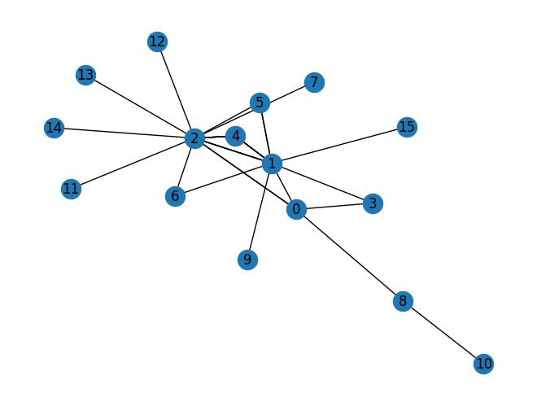

```python
import networkx as nx

num_qubits = 4
num_nodes = 2 ** num_qubits

graph = nx.scale_free_graph(n=num_nodes).to_undirected()
nx.draw(graph, with_labels=True)
```

```
The degree-distribution of the graph's nodes:
```

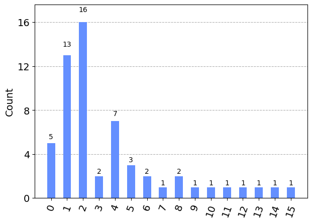

```python
from qiskit.visualization import plot_histogram

print("The degree-distribution of the graph's nodes:")
plot_histogram(dict(graph.degree))
```

I suggest that for now, we will obtain these graphs in a non-online manner, but we will use it in a pseudo-online manner in our algorithm.

## 2. Objective Function Design

Let me reintroduce the following plot, generated on January 2024:

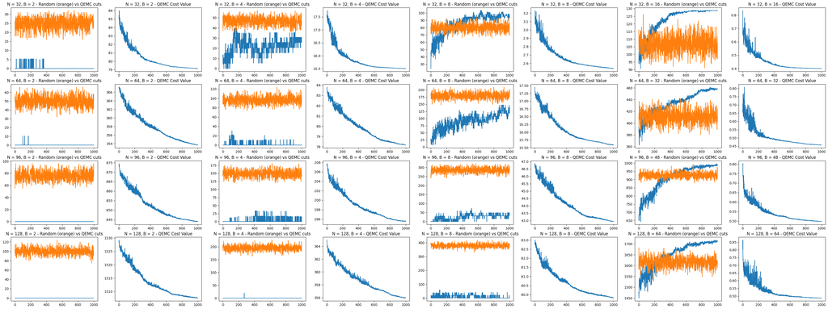

## 2.A Revisiting the QEMC's Cost Function

The (slightly adapted) version of the QEMC's cost function:

$$ L(P) = \sum_{p_i \in P} \sum_{j \in f(i)} \bigg(p_i + p_j - \frac{1}{B} \bigg)^2 + \bigg(|p_i - p_j| - \frac{1}{B} \bigg)^2 \tag{1} $$

Where:

- $P$ is the probability distribution obtained by measuring the Ansatz $S$ times.
- $p_x \in P$ is the probability associated with node $x$.
- $f(x)$ is the set of node-indexes adjacent to the node $x$.

**(A)** Where the distribution $P$ is a uniform distribution $U$ (the trivial, completly noisy case), we obtain:

$$ L(P \approx U) = |P|d \bigg[ \bigg(\frac{2}{|V|} - \frac{1}{B} \bigg)^2 + \bigg(-\frac{1}{B} \bigg)^2 \bigg] = |P|d \bigg[ \frac{2}{B^2} + \frac{4}{|V|^2} - \frac{4}{B|V|} \bigg] \tag{2} $$

**(B)** Where the distribution $P$ represents an optimal partition $P_{\text{opt}}$ (i.e. a MaxCut for a specific $B$ value), we obtain:

$$ L(P \approx P_{\text{opt}}) \approx Bd \bigg[ \bigg(\frac{1}{B} - \frac{1}{B} \bigg)^2 + \bigg(\frac{1}{B} - \frac{1}{B} \bigg)^2 \bigg] + (|V| - B)d \bigg[ \bigg(0 - \frac{1}{B} \bigg)^2 + \bigg(0 - \frac{1}{B} \bigg)^2 \bigg] = (|V| - B)d \frac{2}{B^2} \tag{3} $$

## References

[[1]](https://en.wikipedia.org/wiki/Scale-free_network) **Scale-free network** Wikipedia page.